# Crossover writeup

Josh Chapman & Snuffy Linder & Nate Perfetti

March 6, 2016

# Introduction

In order to save space we decided to abreviate names for our data. The key is given below.

- twopoint_crossover_with_tournament-selection will be tcts
- twopoint_crossover_with_best-half-selection will be tcbhs
- uniform_crossover_with_tournament-selection will be ucts
- uniform_crossover_with_best-half-selection will be ucbhs
- vanilla_hill-climber will be vhc
- random search will be rs

# Experimental problems

# Results

### 20 runs per treatment

```r
data_20_runs <- read.csv("./finaldata.txt", sep="")
```

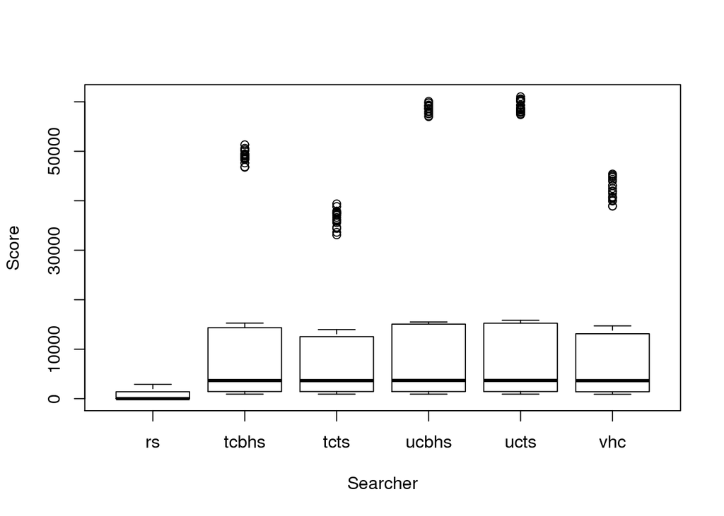

```r
data_20_runs$Non_negative_score = ifelse(data_20_runs$Score<0, 0, data_20_runs$Score)

plot(data_20_runs$Non_negative_score ~ data_20_runs$Search_method,
     xlab="Searcher", ylab="Score")
```

From this graph it shows that our algorithms work much better than random-search. uniform crossover with tournament selection looks like it is doing the best. Vanilla hill climber seems better than two point crossover with tournament selection

```r
pairwise.wilcox.test(data_20_runs$Non_negative_score, data_20_runs$Search_method)
```

```
##
##  Pairwise comparisons using Wilcoxon rank sum test
##
## data:  data_20_runs$Non_negative_score and data_20_runs$Search_method
##
##       rs     tcbhs tcts ucbhs ucts
## tcbhs <2e-16 -     -    -     -
## tcts  <2e-16 1     -    -     -
## ucbhs <2e-16 1     1    -     -
## ucts  <2e-16 1     1    1     -
## vhc   <2e-16 1     1    1     1
##
## P value adjustment method: holm
```

### How do things change by problem?

Let’s load the `ggplot2` package

```r
library("ggplot2")
```

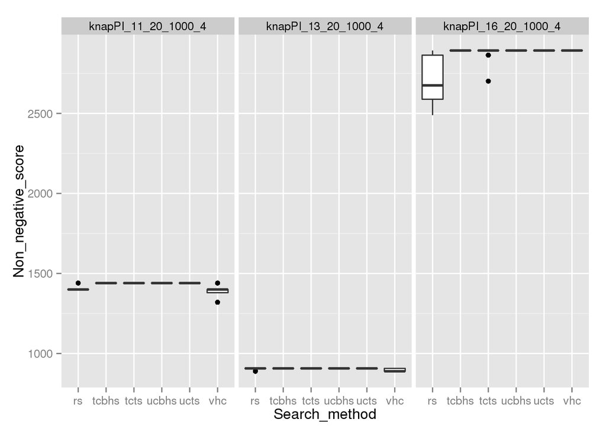

```r
twenty_item_problems = subset(data_20_runs, Problem=="knapPI_11_20_1000_4" | Problem=="knapPI_13_20_1000_4" | Problem=="knapPI_16_20_1000_4")

ggplot(twenty_item_problems, aes(Search_method, Non_negative_score)) + geom_boxplot() + facet_grid(. ~ Problem)
```

Now that we are seperating the different problems we are getting not nearly as much variance, with the exception of random search. This is a pretty good indicator that our algorithm is finding the best solution almost every time.

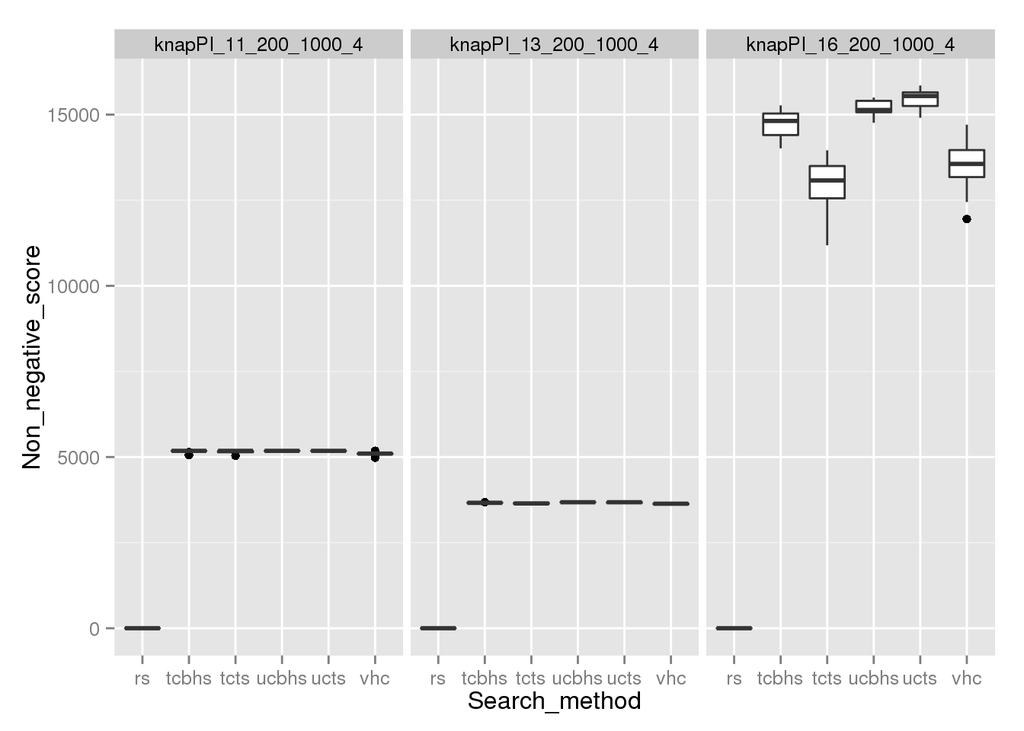

```r
two_hundren_item_problems = subset(data_20_runs, Problem=="knapPI_11_200_1000_4" | Problem=="knapPI_13_200_1000_4" | Problem=="knapPI_16_200_1000_4")

ggplot(two_hundren_item_problems, aes(Search_method, Non_negative_score)) + geom_boxplot() + facet_grid(. ~ Problem)
```

For 11 and 13 we are also getting very little variance. I believe this is because we are getting the best solution everytime. When we get to 16 there is more variance because it is a more difficult problem. It seems to suggest that tournament selection with two point crossover is the worst algorithm other than random search. Uniform crossover with tournament selection does the best.

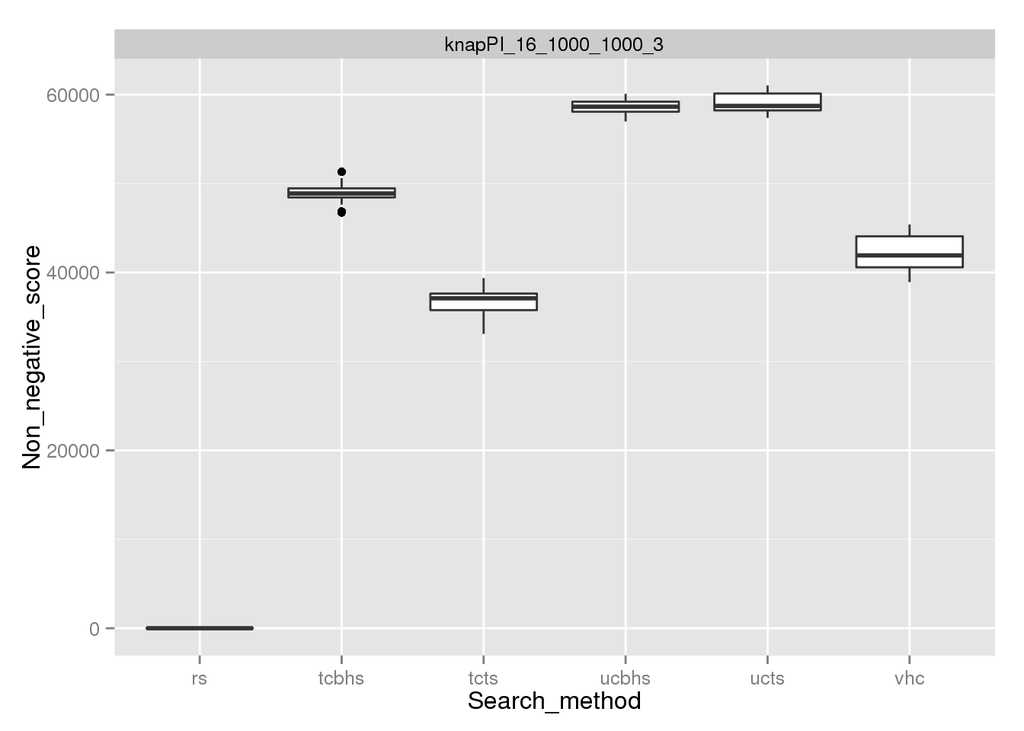

```r
one_thousand_item_problem = subset(data_20_runs, Problem=="knapPI_16_1000_1000_3")

ggplot(one_thousand_item_problem, aes(Search_method, Non_negative_score)) + geom_boxplot() + facet_grid(. ~ Problem)
```

We are getting some variance here, but it seems to suggest the same pattern of data as the previous problems. Although both uniform crossover algorithms are close which we hope means that they are close to the optimal solution.

# Conclusion

All of our algorithms work much better than random search. Two point crossover does better than hill climber only when it uses best half selection. Both forms of uniform crossover are the best although it seems that tournament selection does a little better than best half selection. This is odd as it looks like two point crossover does better with best half selection, and uniform crossover does better with tournament selection. We cannot really figure out why. Our best guess is exploration vs exploytation balance plays a factor.